# VH Study 3v2 Diagnostic: The Same Joint-Growth Model in Mplus and OpenMx

Author

Simulation analysis

Published

August 25, 2026

# 1 Executive summary

This diagnostic asks a narrower question than the main Study 3v2 comparison: does MSEM lose eligibility because the joint two-process growth model is weakly identified in these samples, or because of a software- or parameterization- specific fitting problem? The audit fits the **same 16-parameter model** in OpenMx and pairs it replication by replication with the completed Mplus MSEM results.

The six sentinels contribute 600 paired replications. The overall interval-eligibility rates are 35.2% for Mplus and 34.8% for OpenMx. Both programs are eligible in 34.8% of samples; Mplus alone is eligible in 0.3%, OpenMx alone in 0.0%, and neither in 64.8%.

Among samples that are eligible in both programs, the coefficient correlation is 1.0000 and the mean absolute coefficient difference is 0.00030. This agreement check is essential: eligibility comparisons are interpretable as software diagnostics only if the two implementations converge to the same solution when both succeed.

The result is decisive at the scale this audit was designed to detect. All 307 Mplus critical-warning samples also have an inadmissible OpenMx latent `PSI`. All 82 samples in which Mplus estimation is unavailable are also ineligible in OpenMx. OpenMx rescues **none** of the Mplus failures; conversely, two Mplus-eligible samples receive an OpenMx status-6 indefinite-Hessian result. Thus, switching software does not remedy the low MSEM eligibility in these difficult cells.

# 2 What was matched

The current Mplus helper reshapes each process to one row per cluster and fits two linear latent growth curves. Inspection of the Mplus parameter table shows that `I1`, `S1`, and `I2` are exogenous and therefore have a freely estimated 3-by-3 covariance matrix; `S2` is regressed on `I1` and `S1`; and `I2 WITH S2` is a residual covariance. The OpenMx RAM model reproduces those defaults explicitly.

| Parameter block | Free_parameters | Specification |
| --- | --- | --- |
| Structural regression | 2 | S2 ON I1 S1 |
| Exogenous latent covariance | 6 | Unrestricted covariance of I1, S1, I2 |
| Outcome-slope residual block | 2 | Residual variance of S2; I2 WITH S2 |
| Manifest residual variances | 2 | One equality-constrained variance per process |
| Latent means/intercepts | 4 | Means of I1, S1, I2 and intercept of S2 |
| Total | 16 | Matched in both programs |

The automated test inspects the actual OpenMx `A`, `S`, and mean matrices, including the implicit Mplus `I2 WITH I1` and `I2 WITH S1` paths. It also checks OpenMx’s column-major covariance ordering and verifies the total of 16 free parameters. For eligible smoke-test samples, Mplus and OpenMx coefficients and SEs agree numerically.

# 3 Sentinel conditions

The diagnostic is intentionally compact rather than another crossed simulation factor. Every sentinel uses three balanced observations per process. Conditions 1–5 use 50 clusters and span the four reliability combinations; the low-low null distinguishes weak measurement from pressure caused by the structural path. Condition 6 repeats the hardest low-low large-effect covariance shape at 300 clusters.

| Sentinel | Production condition | N | Predictor reliability | Outcome reliability | rho | beta |
| --- | --- | --- | --- | --- | --- | --- |
| 1. Low-low, null, rho=0, N=50 | 3893 | 50 | 0.25 | 0.25 | 0.0 | 0.0 |
| 2. Low-low, beta=.5, rho=.5, N=50 | 3898 | 50 | 0.25 | 0.25 | 0.5 | 0.5 |
| 3. Low-high, beta=.5, rho=.5, N=50 | 3904 | 50 | 0.25 | 0.80 | 0.5 | 0.5 |
| 4. High-low, beta=.5, rho=.5, N=50 | 3910 | 50 | 0.80 | 0.25 | 0.5 | 0.5 |
| 5. High-high, beta=.5, rho=.5, N=50 | 3916 | 50 | 0.80 | 0.80 | 0.5 | 0.5 |
| 6. Low-low, beta=.5, rho=.5, N=300 | 4546 | 300 | 0.25 | 0.25 | 0.5 | 0.5 |

# 4 Eligibility, coverage, and operational success

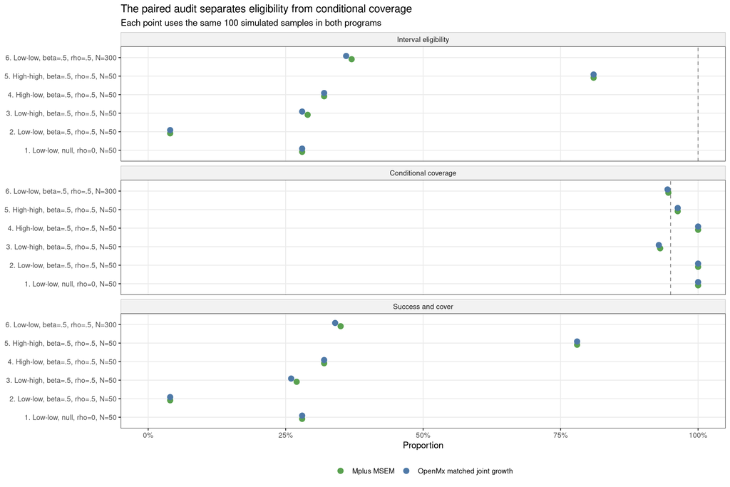

Conditional coverage is calculated only among eligible intervals. Success-and- cover instead counts the probability that a repeated sample produces an eligible interval containing the truth. The paired design makes any difference in those operational quantities considerably more precise than an independent software comparison.

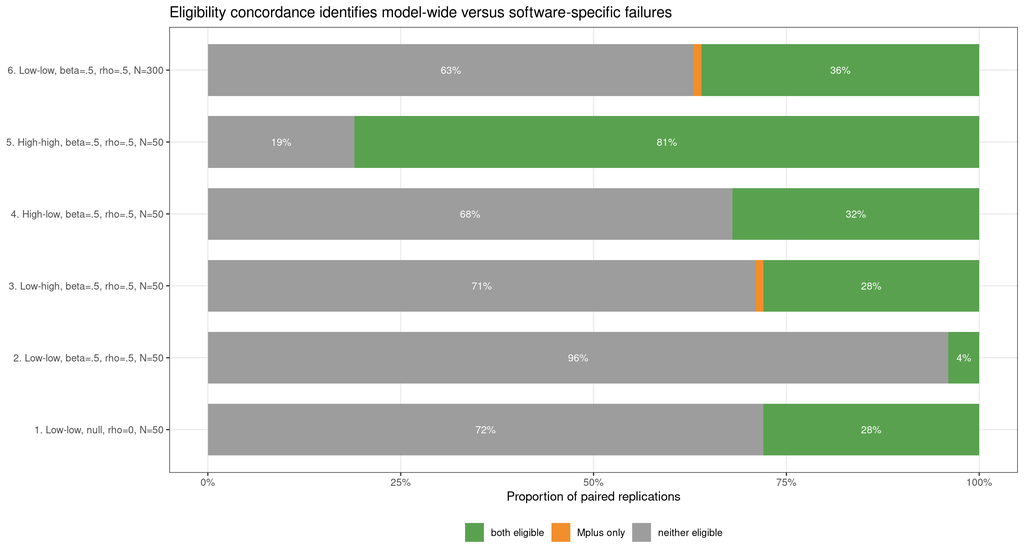

# 5 Do the programs flag the same covariance problem?

The primary OpenMx eligibility definition is deliberately strict. It requires status zero, a finite positive SE, a definite information matrix, and a positive-definite full 4-by-4 latent residual covariance matrix (`PSI`). Mplus eligibility applies the existing production rule: a returned solution with a critical Mplus warning, including a non-positive-definite `PSI`, is excluded.

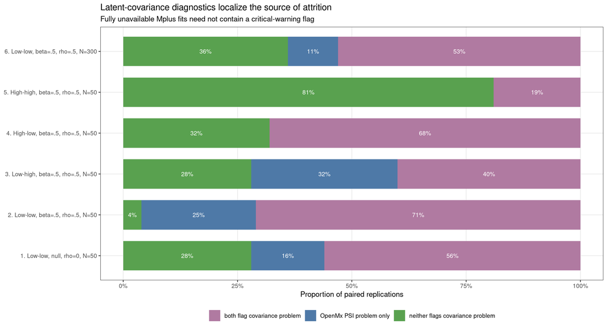

Across the six sentinels, both programs flag a covariance problem in 51.2% of samples. Mplus gives a critical warning while OpenMx reaches an admissible `PSI` solution in 0.0%. These categories should be read with the eligibility disposition: agreement on the covariance problem supports a data/model-information explanation, whereas a large Mplus-warning/ OpenMx-admissible category points to optimizer, starting-value, or parameterization sensitivity.

# 6 Agreement when both programs are eligible

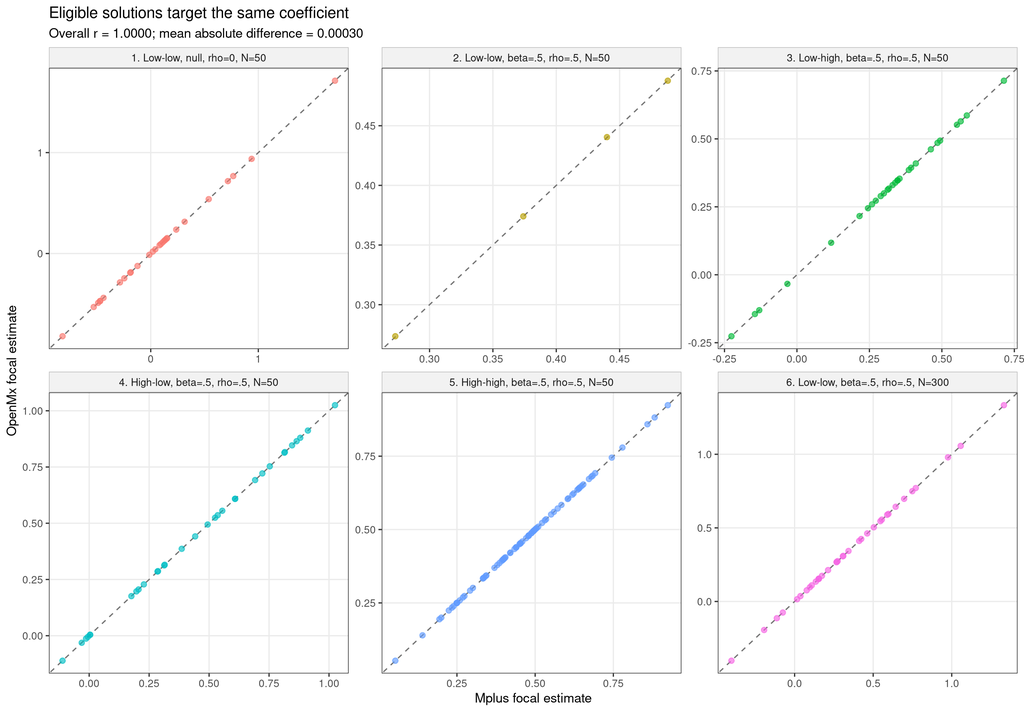

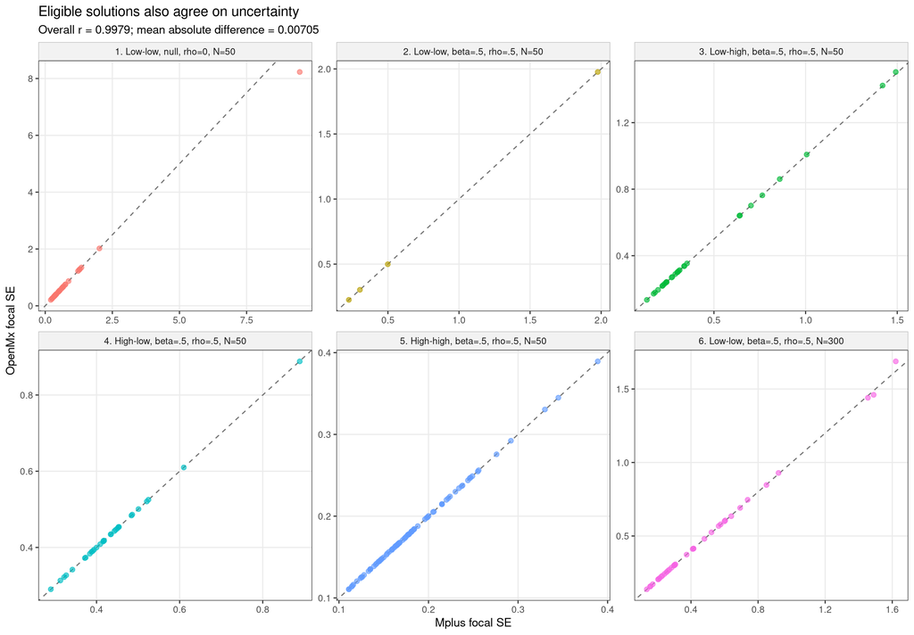

The fixed reporting multiplier is identical in the two programs, so these SEs do not differ because one program applies a delta method to a fitted scaling variance. Agreement therefore tests the likelihood specification, parameter mapping, and information matrix much more directly than comparing MSEM with 2S-PA.

SE agreement is also strong but has one informative tail exception. The median absolute SE difference is 0.00029 and the 99th percentile is 0.0276. The maximum difference, 1.249, occurs in sentinel 1, replication 72, where both SEs are extremely large (Mplus 9.479; OpenMx 8.230). This is consistent with a very flat, boundary-adjacent likelihood rather than a systematic SE scaling mismatch.

# 7 Numerical results

| Sentinel | Method | Interval eligible | Bias | Mean SE | Conditional coverage | Success and cover |
| --- | --- | --- | --- | --- | --- | --- |
| 1. Low-low, null, rho=0, N=50 | Mplus MSEM | 28.0% | 0.067 | 0.974 | 100.0% | 28.0% |
| 1. Low-low, null, rho=0, N=50 | OpenMx matched joint growth | 28.0% | 0.067 | 0.930 | 100.0% | 28.0% |
| 2. Low-low, beta=.5, rho=.5, N=50 | Mplus MSEM | 4.0% | -0.106 | 0.751 | 100.0% | 4.0% |
| 2. Low-low, beta=.5, rho=.5, N=50 | OpenMx matched joint growth | 4.0% | -0.106 | 0.751 | 100.0% | 4.0% |
| 3. Low-high, beta=.5, rho=.5, N=50 | Mplus MSEM | 29.0% | -0.190 | 0.458 | 93.1% | 27.0% |
| 3. Low-high, beta=.5, rho=.5, N=50 | OpenMx matched joint growth | 28.0% | -0.194 | 0.453 | 92.9% | 26.0% |
| 4. High-low, beta=.5, rho=.5, N=50 | Mplus MSEM | 32.0% | -0.052 | 0.436 | 100.0% | 32.0% |
| 4. High-low, beta=.5, rho=.5, N=50 | OpenMx matched joint growth | 32.0% | -0.052 | 0.436 | 100.0% | 32.0% |
| 5. High-high, beta=.5, rho=.5, N=50 | Mplus MSEM | 81.0% | -0.033 | 0.184 | 96.3% | 78.0% |
| 5. High-high, beta=.5, rho=.5, N=50 | OpenMx matched joint growth | 81.0% | -0.033 | 0.184 | 96.3% | 78.0% |
| 6. Low-low, beta=.5, rho=.5, N=300 | Mplus MSEM | 37.0% | -0.108 | 0.624 | 94.6% | 35.0% |
| 6. Low-low, beta=.5, rho=.5, N=300 | OpenMx matched joint growth | 36.0% | -0.149 | 0.490 | 94.4% | 34.0% |

| Sentinel | Both | Mplus only | OpenMx only | Neither | OpenMx - Mplus eligibility | Paired MCSE | Eligible estimate r |
| --- | --- | --- | --- | --- | --- | --- | --- |
| 1. Low-low, null, rho=0, N=50 | 28.0% | 0.0% | 0.0% | 72.0% | 0.0% | 0.0% | 1 |
| 2. Low-low, beta=.5, rho=.5, N=50 | 4.0% | 0.0% | 0.0% | 96.0% | 0.0% | 0.0% | 1 |
| 3. Low-high, beta=.5, rho=.5, N=50 | 28.0% | 1.0% | 0.0% | 71.0% | -1.0% | 1.0% | 1 |
| 4. High-low, beta=.5, rho=.5, N=50 | 32.0% | 0.0% | 0.0% | 68.0% | 0.0% | 0.0% | 1 |
| 5. High-high, beta=.5, rho=.5, N=50 | 81.0% | 0.0% | 0.0% | 19.0% | 0.0% | 0.0% | 1 |
| 6. Low-low, beta=.5, rho=.5, N=300 | 36.0% | 1.0% | 0.0% | 63.0% | -1.0% | 1.0% | 1 |

# 8 Conclusions

The audit was constructed to distinguish three possibilities:

1. **Same estimates and same failures.** This is strong evidence that weak information for the joint growth model, rather than a program-specific bug, causes the attrition.
2. **Same estimates when eligible, but OpenMx is eligible more often.** The estimand and likelihood agree, but numerical strategy matters. Starting values, retry behavior, optimizer choice, or covariance parameterization can determine whether a sample reaches an admissible solution.
3. **Different estimates among mutually eligible fits.** This would indicate a remaining model-specification mismatch and would invalidate the eligibility comparison until resolved.

The observed results match the **first** possibility. The mutually eligible fits agree almost exactly on the focal path, and the eligibility classifications agree in 598 of 600 paired samples. The two disagreements favor Mplus, not OpenMx. Most importantly, every Mplus critical covariance warning is reproduced as an inadmissible latent covariance matrix in OpenMx, and no Mplus-unavailable sample becomes OpenMx-eligible.

Accordingly, the poor MSEM eligibility in Study 3v2 should be interpreted as a property of fitting this relatively elaborate joint growth model with weak level-2 information. It is not explained by a Mplus parsing bug, an overly aggressive warning screen, or a Mplus-specific optimizer failure. The existing success-and-cover analysis therefore remains substantively meaningful: many samples genuinely do not support an admissible joint-model interval.

This finding also changes the priority of possible remedies. Merely porting MSEM to OpenMx is not promising. Remedies would need to change the information or estimator, for example by increasing the number of clusters, improving slope reliability, using a positive-definite covariance parameterization, regularizing weak variance/covariance components, or introducing principled Bayesian priors. Those changes may be useful, but they define modified estimators and must be evaluated for bias and interval calibration; they are not neutral software bug fixes.

## 8.1 Limitations and remaining questions

The audit uses 100 paired replications per sentinel, so a single-cell proportion near 50% has an ordinary Monte Carlo SE of approximately five percentage points. It is designed to discriminate large mechanisms, not to provide final publication-grade performance estimates. The OpenMx path also uses the repository’s `mxTryHard` retry wrapper (up to five attempts), whereas the Mplus rows come from the production fitting path. Any OpenMx advantage therefore establishes **numerical remediability**, but does not by itself prove that the software brand is causal. In fact, OpenMx shows no advantage here even with those retries, which makes optimizer tuning a lower-priority follow-up.

Finally, Mplus prints the saved coefficient and SE to three decimal places, whereas the OpenMx results retain full numerical precision. Small paired differences therefore partly reflect reporting precision. The single large SE difference noted above warrants retaining both programs in any future audit of SE tails, but it does not affect the eligibility conclusion.

# 9 Reproducibility

The audit regenerates every sample using the saved production replication seed and stops if the regenerated and saved seeds disagree. It reads, but never modifies, the Study 3v2 production files. Per-sentinel results are resumable and are stored separately under the diagnostic output directory.

| Sentinel | Production condition | Rows | Unique replications | Complete |
| --- | --- | --- | --- | --- |
| 1 | 3893 | 100 | 100 | TRUE |
| 2 | 3898 | 100 | 100 | TRUE |
| 3 | 3904 | 100 | 100 | TRUE |
| 4 | 3910 | 100 | 100 | TRUE |
| 5 | 3916 | 100 | 100 | TRUE |
| 6 | 4546 | 100 | 100 | TRUE |